# Data Visualization Lab Key

# Part 1

0. Load the libraries

```r
library(readr)
library(ggplot2)
library(dplyr)
library(jhur)
```

0. Read Bike Lanes Dataset using `read_bike()` function from `jhur` package. Assign it to `bike` variable.

Then, use the provided code to compute a data frame `bike_agg` with aggregate summary of bike lanes: average length of lanes (`lane_avg_length`) for each year (`dateInstalled`).

```r
bike <- read_bike()
bike_agg <-
  bike %>%
  # filter data to keep only these observations for which year is non-0
  filter(dateInstalled != 0) %>%
  group_by(dateInstalled) %>%
  summarise(lane_avg_length = mean(length))

bike_agg
```

```
## # A tibble: 8 × 2
##   dateInstalled lane_avg_length
##           <dbl>           <dbl>
## 1          2006           1469.
## 2          2007            310.
## 3          2008            249.
## 4          2009            407.
## 5          2010            246.
## 6          2011            233.
## 7          2012            271.
## 8          2013            290.
```

1. Use `ggplot2` package make plot of average length of lanes (`lane_avg_length`; y-axis) for each year (`dateInstalled`; x-axis). You can use lines layer (`+ geom_line()`) or points layer (`+ geom_point()`), or both!

Assign the plot to variable `my_plot`. Type `my_plot` in the console to have it displayed

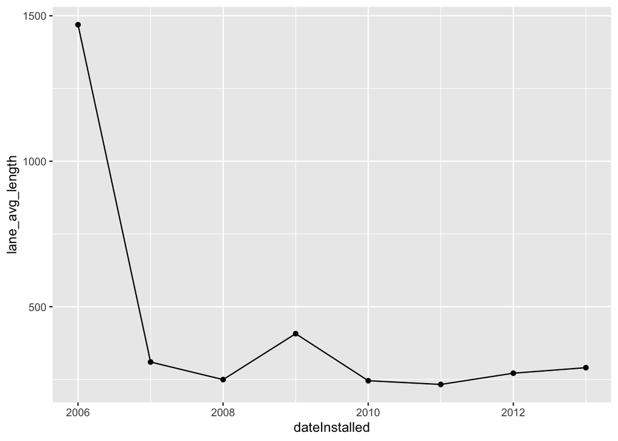

```r
ggplot(bike_agg, aes(x = dateInstalled, y = lane_avg_length)) +
  geom_line() +
  geom_point()
```

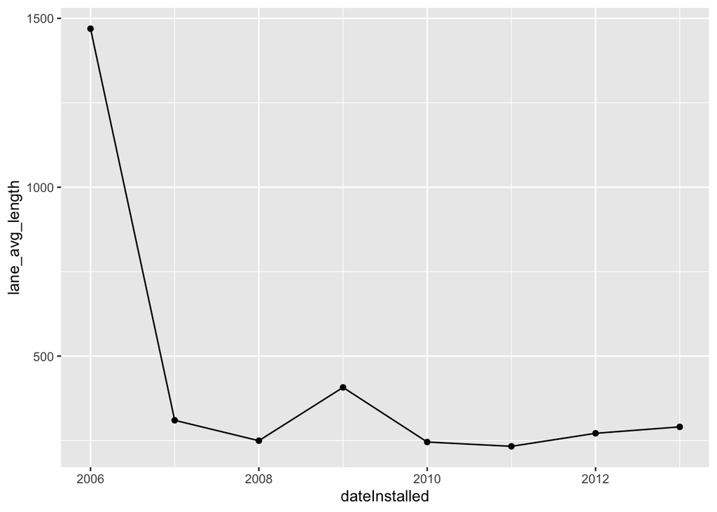

```r
my_plot <-
  ggplot(bike_agg, aes(x = dateInstalled, y = lane_avg_length)) +
  geom_line() +
  geom_point()

my_plot
```

2. “Update” your plot by adding a title and changing the x and y axis titles.

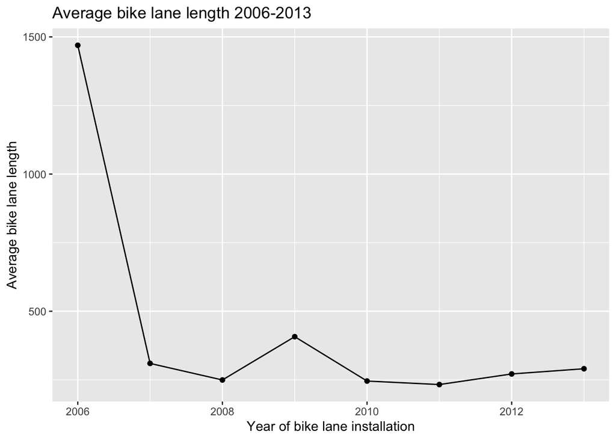

```r
my_plot <-
  my_plot +
  labs(x = "Year of bike lane installation",
       y = "Average bike lane length",
       title = "Average bike lane length 2006-2013")

my_plot
```

3. Use the `scale_x_continuous()` function and its arguments to modify x-axis look. Use `scale_y_continuous()` function and its arguments to modify the y-axis.

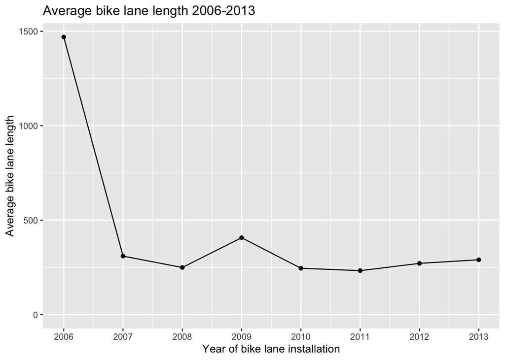

```r
my_plot <-
  my_plot +
  scale_x_continuous(breaks = c(2006, 2007, 2008, 2009, 2010, 2011, 2012, 2013)) +
  scale_y_continuous(limits = c(0, NA))  # force y-axis to start from 0, do not force upper bound

my_plot
```

4. Observe several different versions of the plot by displaying `my_plot` while adding a different “theme” to it.

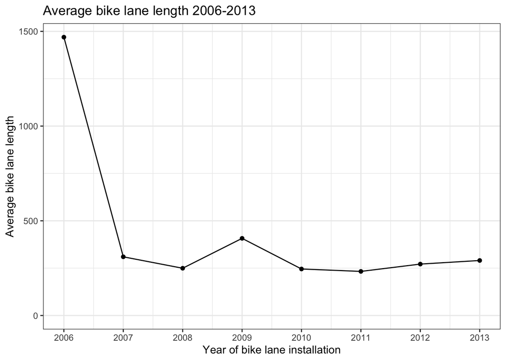

```r
my_plot + theme_bw()
```

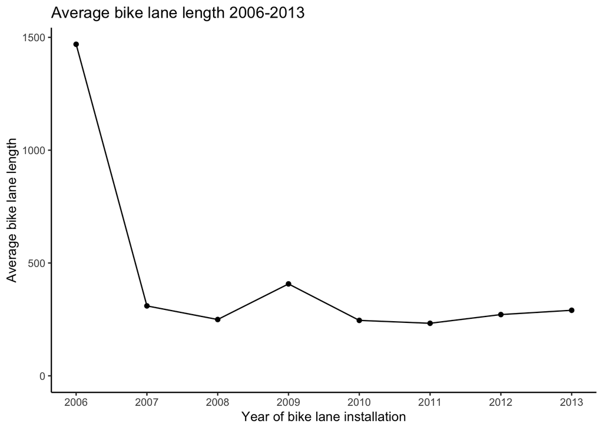

```r
my_plot + theme_classic()
```

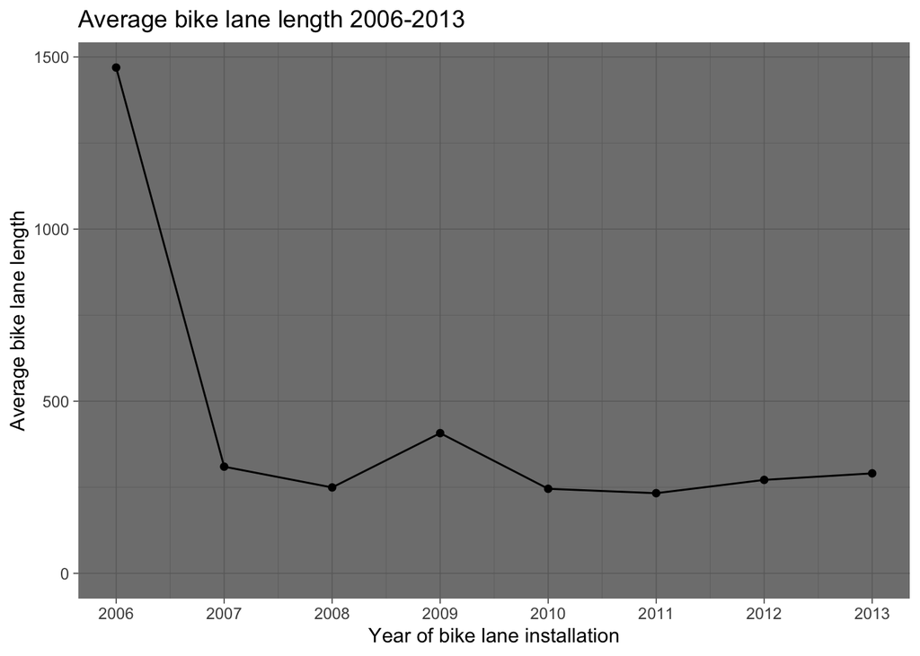

```r
my_plot + theme_dark()
```

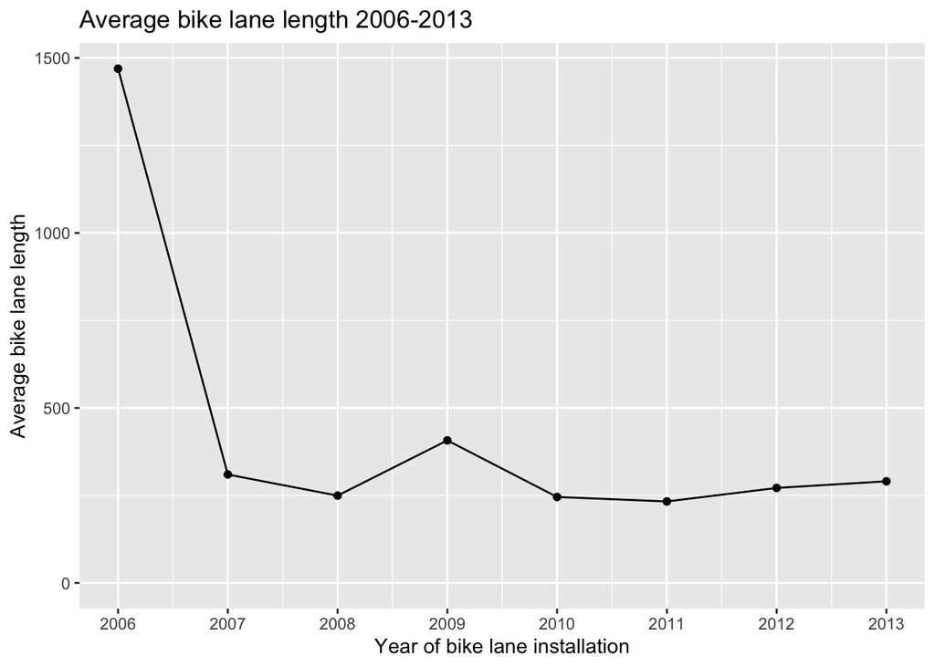

```r
my_plot + theme_gray()
```

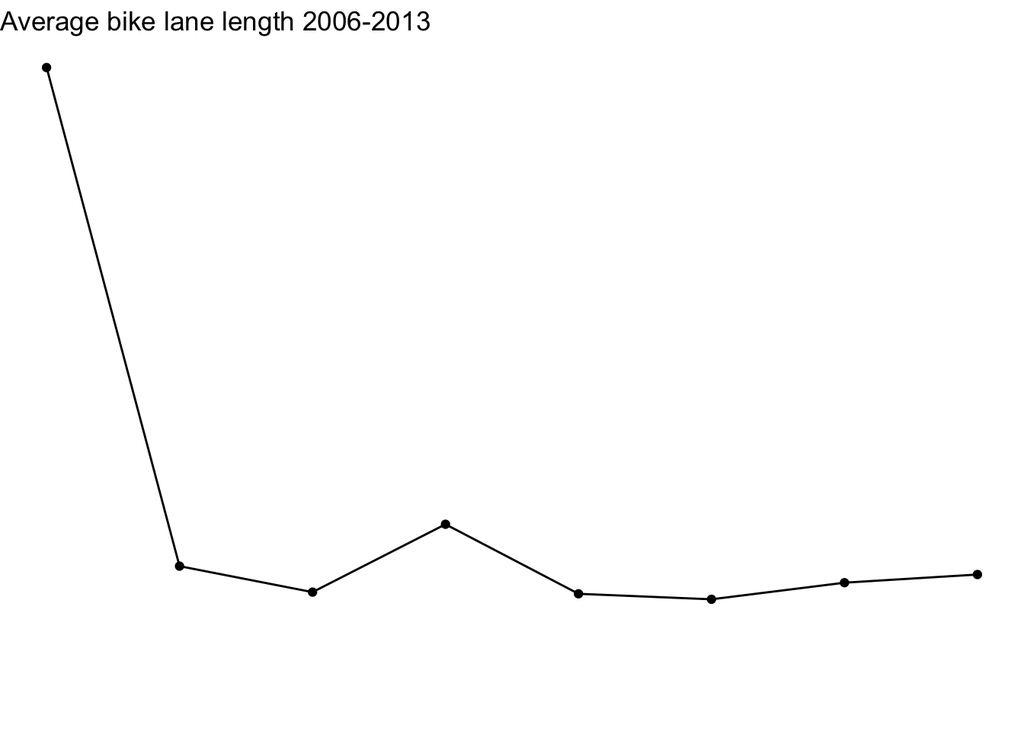

```r
my_plot + theme_void()
```

# Part 2

1. Use the provided code to compute a data frame `bike_agg_2` with aggregate summary of bike lanes: number of lanes (`lane_count`) – separately for each year (`dateInstalled`) and for each lane type.

```r
bike_agg_2 <-
  bike %>%
  filter(dateInstalled != 0) %>%
  group_by(dateInstalled, type) %>%
  summarise(lane_count = n())
bike_agg_2
```

```
## # A tibble: 22 × 3
## # Groups:   dateInstalled [8]
##    dateInstalled type            lane_count
##            <dbl> <chr>                <int>
##  1          2006 BIKE LANE                2
##  2          2007 BIKE LANE              127
##  3          2007 SHARROW                 95
##  4          2007 SIGNED ROUTE           146
##  5          2008 BIKE LANE               55
##  6          2008 SHARROW                148
##  7          2008 SIDEPATH                 3
##  8          2009 BIKE LANE               46
##  9          2009 SHARED BUS BIKE         30
## 10          2009 SHARROW                 10
## # … with 12 more rows
```

2. Use `ggplot2` package to make a plot showing trajectories of number of lanes (`lane_count`; y-axis) over year (`dateInstalled`; x-axis), where each bike line type has a different line with a different color (hint: use `color = type` in mapping).

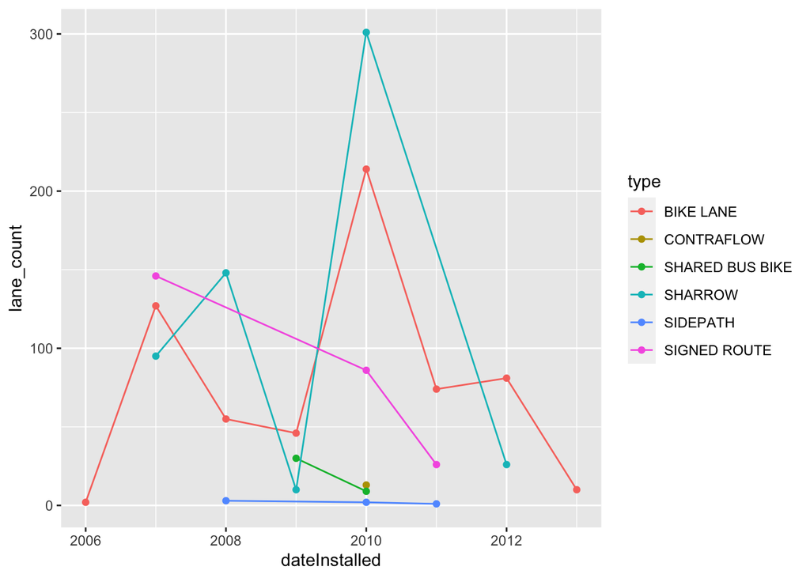

```r
ggplot(bike_agg_2, aes(x = dateInstalled,
                       y = lane_count,
                       color = type)) +
  geom_line() +
  geom_point()
```

3. Redo the above plot by adding a faceting (`+ facet_wrap(~ type, ncol = 3)`) to have data for each bike line type in a separate plot panel.

(You may see `geom_path: Each group consists of only one observation. Do you need to adjust the group aesthetic?` warning as some bike lane types will have only 1 point plotted while trying to plot a line). Save the new plot as an object called `facet_plot`.

```
## geom_path: Each group consists of only one observation. Do you need to adjust
## the group aesthetic?
```

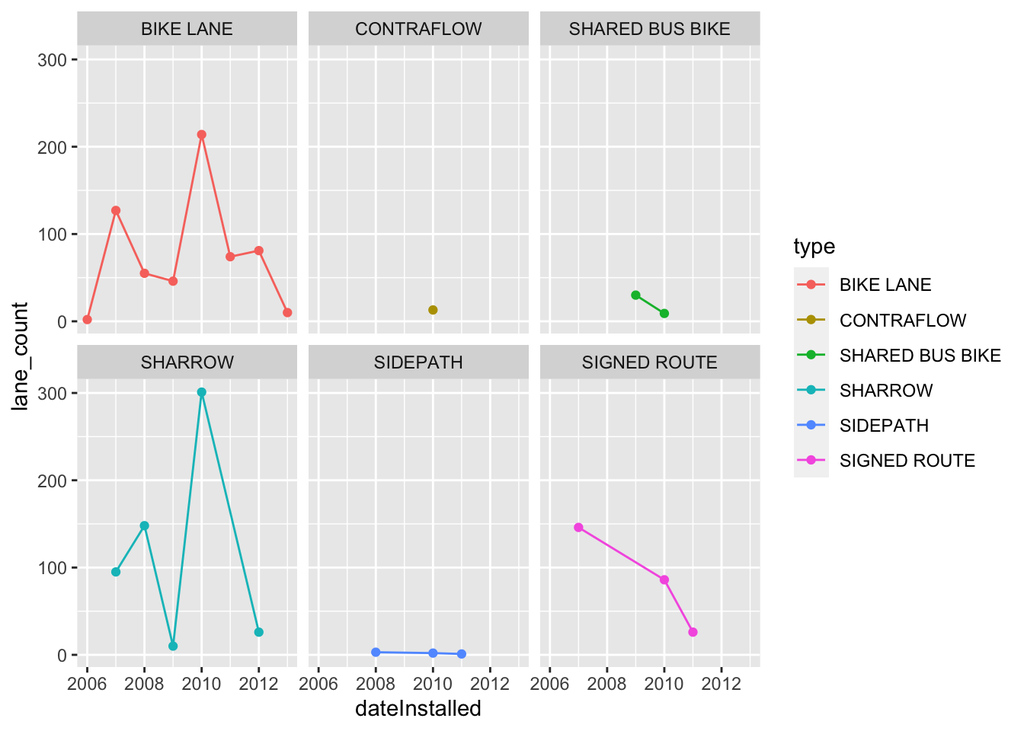

```r
facet_plot <- ggplot(bike_agg_2,
                   aes(x = dateInstalled,
                       y = lane_count,
                       color = type)) +
  geom_line() +
  geom_point() +
  facet_wrap(~ type, ncol = 3)

facet_plot
```

Bonus: Modify `facet_plot` to remove the legend and change the names of the axis titles to be “Number of bike lanes” for the x axis and “Date bike lane was installed” for the y axis.

```
## geom_path: Each group consists of only one observation. Do you need to adjust
## the group aesthetic?
```

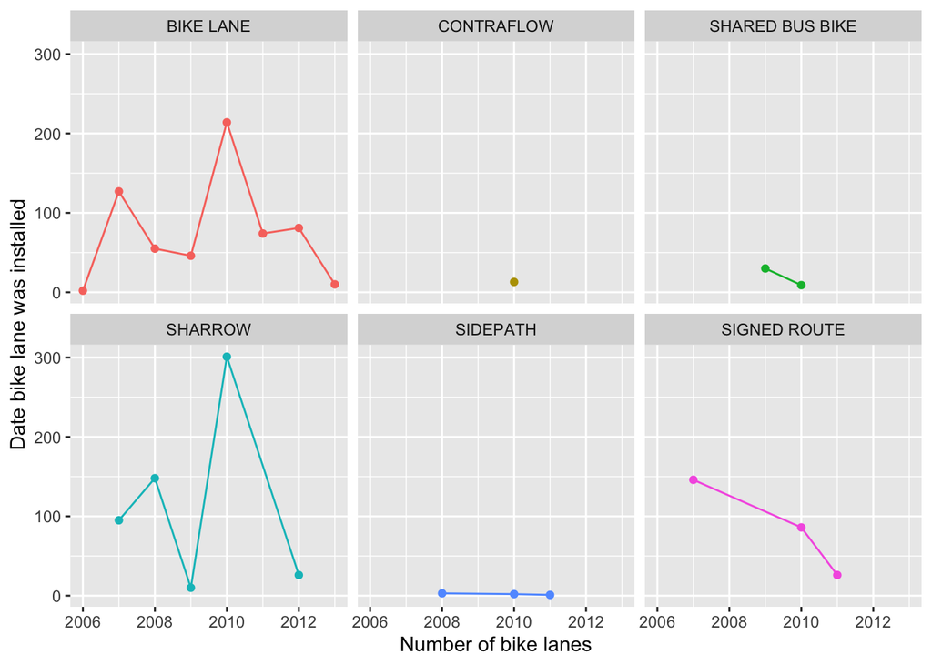

```r
facet_plot <- facet_plot +
  theme(legend.position = "none") +
  labs(x = "Number of bike lanes",
       y = "Date bike lane was installed")
facet_plot
```